# Neanderthal: Last Interglacial Distribution Data

## Overview

The `neanderthal` dataset contains presence and pseudo-absence records of Neanderthal archaeological sites from Marine Isotope Stage 5e (Last Interglacial, ~130,000-115,000 years ago), combined with 25 paleoclimate and topographic predictor variables. This dataset was sourced from [Benito et al. (2017)](https://doi.org/10.1111/jbi.12845) and built to support binary classification, species distribution modelling, and habitat suitability analysis.

## Setup

The code below loads the example data.

```r
data(
  neanderthal,
  neanderthal_response,
  neanderthal_predictors,
  package = "spatialData"
)
```

## Data Structure

```r
dplyr::glimpse(neanderthal)
```

```
#> Rows: 227
#> Columns: 27
#> $ presence             <int> 1, 1, 1, 1, 1, 1, 1, 1, 1, 1, 1, 1, 1, 1, 1, 1, 1…
#> $ bio1                 <dbl> 93.90861, 101.39613, 98.43701, 80.31912, 67.72340…
#> $ bio10                <dbl> 230.8535, 193.2386, 196.0572, 208.2075, 193.7100,…
#> $ bio11                <dbl> -40.628402, 19.409437, 7.986982, -47.536219, -58.…
#> $ bio12                <dbl> 1016.7842, 634.9449, 651.3601, 481.9939, 598.3581…
#> $ bio13                <dbl> 124.79270, 86.20893, 78.12757, 64.77663, 79.24467…
#> $ bio14                <dbl> 42.9601370, 20.1204209, 23.6468781, 17.5191646, 2…
#> $ bio15                <dbl> 28.78959, 34.29474, 27.51153, 40.68027, 36.12821,…
#> $ bio16                <dbl> 321.4307, 235.2489, 220.1406, 189.4942, 228.7584,…
#> $ bio17                <dbl> 141.42826, 103.49764, 107.45727, 59.94072, 84.456…
#> $ bio18                <dbl> 306.99387, 125.23646, 155.59023, 179.19781, 213.6…
#> $ bio19                <dbl> 174.55667, 150.36287, 140.85947, 60.03907, 84.465…
#> $ bio2                 <dbl> 107.35804, 80.55478, 86.42271, 101.75828, 100.366…
#> $ bio3                 <dbl> 24.97327, 29.14201, 29.00000, 24.82866, 24.62171,…
#> $ bio4                 <dbl> 10434.941, 6795.361, 7319.844, 9877.545, 9766.644…
#> $ bio5                 <dbl> 315.4290, 259.6066, 268.1590, 290.8134, 275.5202,…
#> $ bio6                 <dbl> -109.914922, -12.303463, -26.610513, -115.376691,…
#> $ bio7                 <dbl> 425.3439, 271.9101, 294.7695, 406.1901, 401.8273,…
#> $ bio8                 <dbl> 219.387741, 95.264316, 89.376189, 200.248222, 186…
#> $ bio9                 <dbl> -23.84609, 52.21129, 49.78763, -41.15274, -58.285…
#> $ topo_aspect          <dbl> 203.37818, 149.00686, 169.84060, 142.45523, 149.4…
#> $ topo_diversity_local <dbl> 7.1118334, 6.2437519, 1.2860197, -3.1426907, -0.7…
#> $ topo_diversity       <dbl> 78.13295, 74.73658, 73.03239, 67.50587, 71.77473,…
#> $ topo_elev            <dbl> 240.97322, 62.10563, 32.56124, 110.95158, 348.351…
#> $ topo_slope           <dbl> 2.0600362, 0.9570366, 0.3261872, 1.3632851, 1.354…
#> $ topo_wetness         <dbl> -3.142004, -3.236383, -1.925804, -3.006190, -4.24…
#> $ geometry             <POINT [°]> POINT (15.8632 46.1654), POINT (1.8785 50.1…
```

## Response Variable

The response variable is `presence`, a binary variable indicating Neanderthal presence (1) or pseudo-absence (0):

```r
table(neanderthal$presence)
```

```
#>
#>   0   1
#> 178  49
```

```r
mapview::mapview(
  neanderthal |>
    dplyr::mutate(
      presence = as.factor(presence)
    ),
  zcol = "presence",
  layer.name = "Presence"
)
```

[interactive chart not shown]

## Predictor Variables

The dataset includes **25 predictor variables** organized into two categories:

| Category | Variables | Description |
| --- | --- | --- |
| Bioclimatic (19) | `bio1` to `bio19` | Temperature and precipitation variables reconstructed for the Last Interglacial |
| Topographic (6) | `topo_aspect`, `topo_diversity_local`, `topo_diversity`, `topo_elev`, `topo_slope`, `topo_wetness` | Terrain characteristics |

## Example Usage

This example shows how `neanderthal` can be used to model Neanderthal habitat suitability using an weighted-average ensemble of quasibinomial GAMs with case weights.

### Multicollinearity Filtering

Many predictors in this dataset are correlated (e.g., temperature-derived bioclimatic variables). The function [`collinear::collinear()`](https://blasbenito.github.io/collinear/reference/collinear.html) selects a non-redundant subset that maximizes predictive power. To do so, the code below first ranks the predictors by the AUC of univariate binomial GAM models with case weights, and then applies a multicollinearity filtering that preserves the most important predictors.

```r
selection <- collinear::collinear(
  df = neanderthal,
  responses = "presence",
  predictors = neanderthal_predictors,
  f = collinear::f_binomial_gam,
  quiet = TRUE
)
```

The ranking of predictors computed by `colliinear::collinear()` for this dataset is shown below. The column `score` shows the AUC score of each univariate model.

```r
DT::datatable(selection$presence$preference_order[, c("response", "predictor", "score")])
```

|  | response | predictor | score |
| --- | --- | --- | --- |
| 1 | presence | bio17 | 0.8748 |
| 2 | presence | bio12 | 0.8665 |
| 3 | presence | bio19 | 0.8638 |
| 4 | presence | bio14 | 0.8412 |
| 5 | presence | bio1 | 0.8343 |
| 6 | presence | bio7 | 0.8143 |
| 7 | presence | bio2 | 0.8084 |
| 8 | presence | bio11 | 0.8037 |
| 9 | presence | bio8 | 0.7999 |
| 10 | presence | topo_slope | 0.7997 |

[output cut: 15 more lines]

The function has selected the following predictors:

```r
selection$presence$selection
```

```
#> [1] "bio17"          "bio1"           "bio7"           "bio8"
#> [5] "topo_slope"     "bio13"          "topo_diversity" "topo_wetness"
#> [9] "topo_aspect"
#> attr(,"validated")
#> [1] TRUE
```

As a plus, `collinear::collinear()` also has a GAM formula ready for us:

```r
selection$presence$formulas$smooth
```

```
#> presence ~ s(bio17) + s(bio1) + s(bio7) + s(bio8) + s(topo_slope) +
#>     s(bio13) + s(topo_diversity) + s(topo_wetness) + s(topo_aspect)
#> <environment: 0x5f3f8bbaf4d0>
```

### Modelling

In this section we fit a weighted ensemble of quasibinomial GAM models with case weights.

**Case weights**: The `neanderthal` dataframe has 49 and 178 absences, an imbalance that might result in an overprediction of zeros. To mitigate this issue, the function [`collinear::case_weights()`](https://blasbenito.github.io/collinear/reference/case_weights.html) generates inverse-frequency weights so that both classes contribute equally to the model fit.

```r
sample_weights <- collinear::case_weights(x = neanderthal$presence)
table(sample_weights)
```

```
#> sample_weights
#> 0.00280898876404494  0.0102040816326531
#>                 178                  49
```

**Quasibinomial GAM**: A standard binomial GLM assumes a linear predictor–response relationship, which is too restrictive for ecological data where species responses to climate are often non-linear. A GAM replaces the linear terms with smoothing splines (`s()`), letting the data determine the shape of each response curve. We use the `quasibinomial` family because it accounts for the overdispersion introduced by pseudo-absence data and case weights.

**Weighted Ensemble**: The `neanderthal` data has 49 presences. Fitting a model with all predictors at once might lead to overparameterization, which might in turn lead to overfitting. To avoid this potential issue, we will fit univariate GAM models, and then compute the weighted average of their predictions, using each model’s AUC score as weight.

The code below fits the univariate GAM models.

```r
models <- lapply(
  X = selection$presence$selection,
  FUN = function(x){

    mgcv::gam(
      formula = as.formula(paste0("presence ~ s(", x, ", k = 4)")),
      data = sf::st_drop_geometry(neanderthal),
      family = stats::quasibinomial(link = "logit"),
      weights = sample_weights,
      REML = TRUE,
      select = TRUE
    )

  }
)

names(models) <- selection$presence$selection
```

The following plots show the fitted response curves for each univariate GAM model. Each curve represents the predicted probability of Neanderthal presence as a function of a single predictor, with 95% confidence intervals shown as shaded ribbons. Rug marks along the x-axis indicate observed data values.

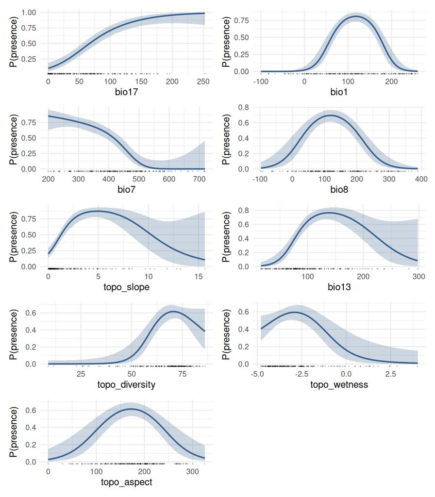

```r
response_plots <- lapply(names(models), function(var) {

  model <- models[[var]]
  df <- sf::st_drop_geometry(neanderthal)

  # prediction grid across predictor range
  newdata <- data.frame(x = seq(min(df[[var]]), max(df[[var]]), length.out = 200))
  names(newdata) <- var

  # predict on link scale with standard errors
  pred <- predict(model, newdata = newdata, type = "link", se.fit = TRUE)

  # back-transform to probability scale with 95% CI
  newdata$fit   <- plogis(pred$fit)
  newdata$lower <- plogis(pred$fit - 1.96 * pred$se.fit)
  newdata$upper <- plogis(pred$fit + 1.96 * pred$se.fit)

  ggplot(newdata, aes(x = .data[[var]])) +
    geom_ribbon(
      aes(ymin = lower, ymax = upper),
      fill = viridis::viridis(1, begin = 0.3),
      alpha = 0.25
    ) +
    geom_line(
      aes(y = fit),
      color = viridis::viridis(1, begin = 0.3),
      linewidth = 0.8
    ) +
    geom_rug(
      data = df,
      aes(x = .data[[var]]),
      sides = "b",
      alpha = 0.3,
      length = unit(0.02, "npc")
    ) +
    labs(x = var, y = "P(presence)") +
    theme_minimal(base_size = 11)
})

patchwork::wrap_plots(response_plots, ncol = 2)
```

We also need their respective AUC scores to be used as weights when building the ensemble. Here these scores are computed via [collinear::score_auc()](https://blasbenito.github.io/collinear/reference/score_auc.html).

```r
model_weights <- lapply(
  X = models,
  FUN = function(x){

    collinear::score_auc(
      o = neanderthal[["presence"]],
      p = stats::predict(x, type = "response")
    )

  }
) |>
  unlist()

names(model_weights) <- selection$presence$selection
```

|  | model_weights |
| --- | --- |
| bio17 | 0.8235 |
| bio1 | 0.8286 |
| bio7 | 0.805 |
| bio8 | 0.7001 |
| topo_slope | 0.7981 |
| bio13 | 0.7864 |
| topo_diversity | 0.6861 |
| topo_wetness | 0.6056 |
| topo_aspect | 0.6305 |

To compute the intrinsic AUC of the model, we average it’s predictions, and compare them with the observations.

```r
#extract predictions from each model
predictions <- sapply(
  X = models,
  FUN = function(x) {
    stats::predict(x, type = "response")
  }
)

#compute weighted average predictions
weighted_predictions <- apply(
  X = predictions,
  MARGIN = 1,
  FUN = stats::weighted.mean,
  w = model_weights
)

#compute ensemble AUC
ensemble_auc <- collinear::score_auc(
  o = neanderthal[["presence"]],
  p = weighted_predictions
)

ensemble_auc
```

```
#> [1] 0.923756
```

The ensemble AUC indicates how well the weighted combination of univariate models discriminates between presence and pseudo-absence sites.

### Habitat Suitability Map

The package provides the raster dataset `neanderthal_env` to predict models based on the `neanderthal` data.

```r
neanderthal_env <- spatialData::neanderthal_extra()
class(neanderthal_env)
```

```
#> [1] "SpatRaster"
#> attr(,"package")
#> [1] "terra"
```

```r
names(neanderthal_env)
```

```
#>  [1] "bio1"                 "bio10"                "bio11"
#>  [4] "bio12"                "bio13"                "bio14"
#>  [7] "bio15"                "bio16"                "bio17"
#> [10] "bio18"                "bio19"                "bio2"
#> [13] "bio3"                 "bio4"                 "bio5"
#> [16] "bio6"                 "bio7"                 "bio8"
#> [19] "bio9"                 "topo_aspect"          "topo_diversity_local"
#> [22] "topo_diversity"       "topo_elev"            "topo_slope"
#> [25] "topo_wetness"
```

The map below shows the fitted habitat suitability for Neanderthals during the Last Interglacial.

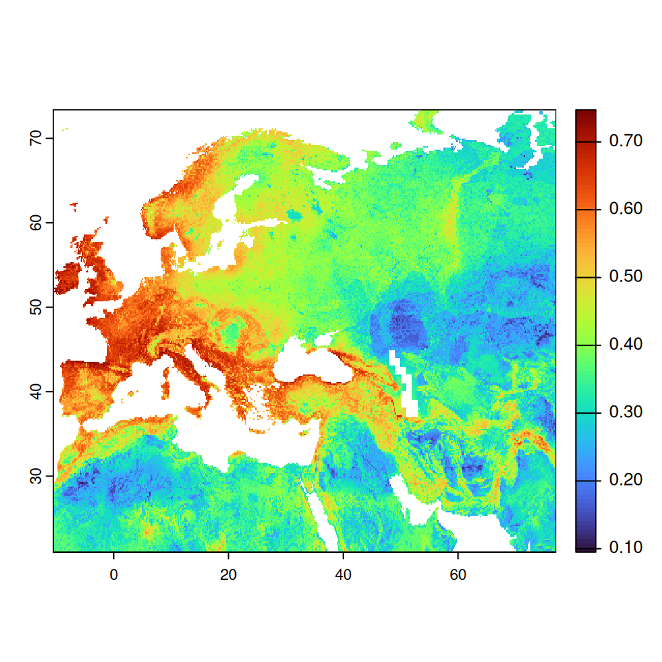

```r
#predict each model on a separate raster object
raster_predictions <- lapply(
  X = names(models),
  FUN = function(x) {
    terra::predict(
      object = neanderthal_env,
      model = models[[x]],
      type = "response",
      na.rm = TRUE
    )
  }
) |>
  terra::rast()

#compute weighted mean of individual predictions
neanderthal_suitability <- terra::weighted.mean(
  x = raster_predictions,
  w = model_weights
)

#plot suitability map
plot(
  x = neanderthal_suitability,
  col = viridis::turbo(n = 100)
)
```

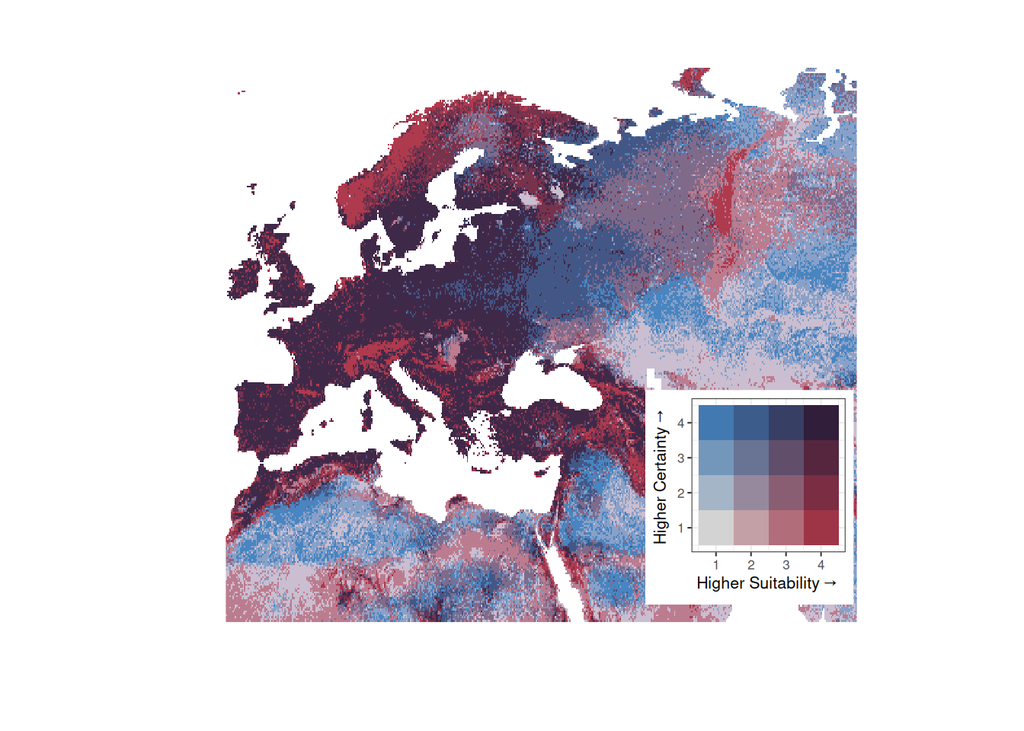

```r
#compute standard deviation across models
neanderthal_sd <- terra::app(
  x = raster_predictions,
  fun = "sd"
)

#combine into a data frame for biscale
bi_df <- terra::as.data.frame(
  x = c(neanderthal_suitability, neanderthal_sd),
  xy = TRUE
)
names(bi_df)[3:4] <- c("suitability", "uncertainty")

#invert uncertainty so darker colors mean higher certainty
bi_df$certainty <- max(bi_df$uncertainty) - bi_df$uncertainty

#classify into bivariate classes
bi_df <- biscale::bi_class(
  .data = bi_df,
  x = suitability,
  y = certainty,
  style = "quantile",
  dim = 3
)

#build bivariate map
bi_map <- ggplot2::ggplot(data = bi_df) +
  ggplot2::geom_raster(
    mapping = ggplot2::aes(x = x, y = y, fill = bi_class)
  ) +
  biscale::bi_scale_fill(pal = "DkViolet", dim = 3) +
  ggplot2::coord_quickmap() +
  biscale::bi_theme() +
  ggplot2::theme(legend.position = "none") +
  ggplot2::labs(x = "", y = "")

#build legend
bi_legend <- biscale::bi_legend(
  pal = "DkViolet2",
  dim = 4,
  xlab = "Higher Suitability",
  ylab = "Higher Certainty"
) +
  ggplot2::theme_bw(
    base_size = 8
  )

#compose map and legend
bi_map + patchwork::inset_element(
  p = bi_legend,
  left = 0.65,
  bottom = -0.1,
  right = 0.95,
  top = 0.6
  )
```